# Using Text Mining To Predict Prices - Part 2

Linear Regression with Text Data

```r
library(readr)
library(dplyr)
library(tidytext)
library(tm)
library(ggplot2)
library(ggridges)
require(quanteda)

rm(list=ls())
col <- RColorBrewer::brewer.pal(5, "Dark2")

options(stringsAsFactors = FALSE)
knitr::opts_chunk$set(message=FALSE, warning=FALSE)
```

```r
load(file="../output/prep2.Rda")
```

Can we improve the model from [part 2](https://franziloew.github.io/airbnb_textmining/linreg_text.html) including the description text of the listing on the right-hand side of the model?

As before, we wish to predict the price $y_i$ for each Airbnb listing $i$ based on some independent variables $X$. In this model the text counts $c_i$ of each listing description are used. This is a regression problem like any other, except that the high-dimensionality of $c_i$ makes OLS and other standard techniques infeasible.

Here, we have $d=20.637$ documents (aka Airbnb listings) each of which is $w$ words long. Each word is drawn from a vocabulary of $p=33.469$ possible words. The unique representation of each document has dimension $p^w$. A common strategy to deal with the high-dimensionality of text data is the estimation of penalized linear models, particularly with $L_1$ penalization (Gentzkow, 2017).

However, a first step to use textdata in a prediction model is to convert it to a Document Term Matrix, where each row is a observation (document) and each column is a unique term.

```r
corp <- Corpus(VectorSource(df$text_cleaned))
dtm <- DocumentTermMatrix(corp)

dtm
```

```
## <<DocumentTermMatrix (documents: 20637, terms: 33469)>>
## Non-/sparse entries: 650794/690048959
## Sparsity           : 100%
## Maximal term length: 132
## Weighting          : term frequency (tf)
```

The first five observations of the Document Term Matrix look like this:

```r
inspect(dtm[1:5, 1:10])
```

```
## <<DocumentTermMatrix (documents: 5, terms: 10)>>
## Non-/sparse entries: 10/40
## Sparsity           : 80%
## Maximal term length: 18
## Weighting          : term frequency (tf)
## Sample             :
##     Terms
## Docs ausgerichtete ausgestattet bad badewanne befindet erdgeschoß
##    1             1            1   1         1        1          1
##    2             0            0   0         0        0          0
##    3             0            0   0         0        0          0
##    4             0            0   0         0        0          0
##    5             0            0   0         0        0          0
##     Terms
## Docs erdgeschosswohnung essplatz flatscreen frühstück
##    1                  1        1          1         1
##    2                  0        0          0         0
##    3                  0        0          0         0
##    4                  0        0          0         0
##    5                  0        0          0         0
```

Matrices in text analysis problems tend to be very sparse. That is, most of the elements are zero, which implies that they have many parameters that are uninformative. (In contrast: a dense matrix is a matrix in which most of the elements are nonzero.)

```r
# Here we are reducing the sparsity of the document-term matrix so that the sparsity (% of non-zeros) is a maximum of 99%.
dtm<-removeSparseTerms(dtm,0.99)
dtm
```

```
## <<DocumentTermMatrix (documents: 20637, terms: 586)>>
## Non-/sparse entries: 403573/11689709
## Sparsity           : 97%
## Maximal term length: 21
## Weighting          : term frequency (tf)
```

```r
inspect(dtm[1:5, 1:10])
```

```
## <<DocumentTermMatrix (documents: 5, terms: 10)>>
## Non-/sparse entries: 10/40
## Sparsity           : 80%
## Maximal term length: 12
## Weighting          : term frequency (tf)
## Sample             :
##     Terms
## Docs ausgestattet bad badewanne befindet gelegen gemütlichen gibt große
##    1            1   1         1        1       1           1    1     3
##    2            0   0         0        0       0           0    0     0
##    3            0   0         0        0       0           0    0     0
##    4            0   0         0        0       0           0    0     0
##    5            0   0         0        0       0           0    0     0
##     Terms
## Docs großem gut
##    1      1   1
##    2      0   0
##    3      0   0
##    4      0   0
##    5      0   0
```

```r
# Convert to Dataframe
dtm.df <- as.matrix(dtm) %>%
  as.data.frame()

# Merge with orignal dataframe
dtm.df$document <-as.integer(rownames(dtm.df))
df$document <- as.integer(rownames(df))

df.reg <- dtm.df %>%
  left_join(df %>%
              select(document, price),
            by = "document") %>%
  filter(price != 0) %>%
  mutate(log_price = log(price)) %>%
  select(-document, -price)
```

## (1) Training / Test

```r
#create test and training sets
bound <- floor((nrow(df.reg)/4)*3)         #define % of training and test set

df.reg <- df.reg[sample(nrow(df.reg)), ]           #sample rows
df.train <- df.reg[1:bound, ]              #get training set
df.test <- df.reg[(bound+1):nrow(df.reg), ]    #get test set
```

In [part 1](https://franziloew.github.io/airbnb_textmining/data_prep.html) we saw that our dependent variable is left-skewed. This is somehow problematic, as the linear regression assumes normal distributed data. A common strategy to deal with left-skewed data is to take the logarithmic values (log-level model). Lets have a look at the log distributions.

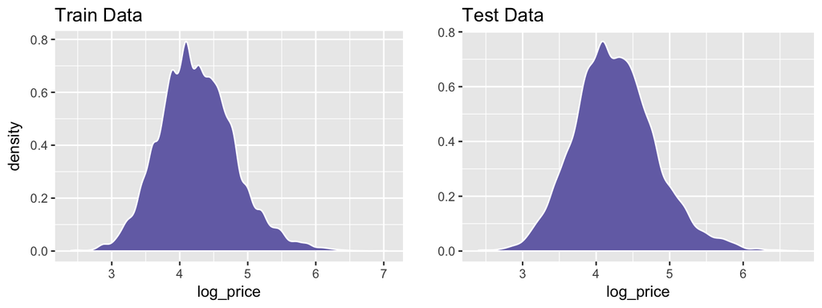

```r
p1 <- ggplot(df.train, aes(log_price)) +
  geom_density(fill = col[3], color = "white") +
  labs(title = "Train Data")

p2 <- ggplot(df.test, aes(log_price)) +
  geom_density(fill = col[3], color = "white") +
  labs(y="", title = "Test Data")

gridExtra::grid.arrange(p1, p2, nrow = 1)
```

## Linear Regression

### (2) Estimate Training Data

```r
lm.train <- lm(log_price~., data = df.train)

summary(lm.train)
```

```
##
## Call:
## lm(formula = log_price ~ ., data = df.train)
##
## Residuals:
##      Min       1Q   Median       3Q      Max
## -2.14872 -0.28551 -0.01697  0.26163  2.49194
##
## Coefficients:
##                         Estimate Std. Error t value Pr(>|t|)
## (Intercept)            4.229e+00  9.944e-03 425.252  < 2e-16 ***
## ausgestattet          -4.967e-03  1.767e-02  -0.281 0.778617
## bad                   -1.309e-02  1.428e-02  -0.916 0.359438
## badewanne             -5.867e-03  2.358e-02  -0.249 0.803486
## befindet              -1.821e-02  1.136e-02  -1.603 0.108949
## gelegen               -9.788e-03  1.562e-02  -0.626 0.531039
## gemütlichen           -3.892e-02  2.432e-02  -1.600 0.109558
## gibt                  -2.062e-03  1.227e-02  -0.168 0.866579
## große                  6.693e-02  1.480e-02   4.522 6.18e-06 ***
## großem                -1.402e-02  2.673e-02  -0.524 0.600070
## gut                   -1.905e-02  1.609e-02  -1.184 0.236507
## küche                 -2.018e-02  1.246e-02  -1.619 0.105424
## lädt                  -1.251e-02  3.574e-02  -0.350 0.726285
## moderne                1.102e-01  2.180e-02   5.053 4.40e-07 ***
## schlafzimmer           1.218e-01  1.486e-02   8.198 2.65e-16 ***
## schönes               -5.673e-02  1.766e-02  -3.212 0.001319 **
## terrasse               1.136e-01  2.301e-02   4.937 8.04e-07 ***
## vorhanden              1.483e-02  1.841e-02   0.805 0.420676
## wlan                   5.091e-02  1.873e-02   2.718 0.006579 **
## wohnung                4.484e-02  5.636e-03   7.956 1.91e-15 ***
## wohnzimmer             2.721e-02  1.513e-02   1.798 0.072184 .
## apartment              7.087e-02  5.628e-03  12.591  < 2e-16 ***
## around                 5.209e-04  2.102e-02   0.025 0.980226
## balcony                4.127e-03  1.218e-02   0.339 0.734658
## bed                    1.103e-02  1.367e-02   0.807 0.419599
## bright                -2.633e-02  1.306e-02  -2.016 0.043773 *
## central                2.210e-02  9.932e-03   2.225 0.026091 *
## city                   1.793e-02  9.215e-03   1.946 0.051695 .
## corner                -9.113e-03  2.799e-02  -0.326 0.744780
## cozy                  -4.201e-02  1.091e-02  -3.851 0.000118 ***
```

[output cut: 548 more lines]

```
## gästezimmer           -1.616e-01  2.358e-02  -6.852 7.57e-12 ***
## museum                 1.280e-02  2.637e-02   0.485 0.627419
## bar                    7.487e-02  3.273e-02   2.288 0.022180 *
## frankfurter           -5.834e-03  3.328e-02  -0.175 0.860835
## natürlich             -3.332e-02  3.048e-02  -1.093 0.274339
## eigenes               -5.857e-02  3.449e-02  -1.698 0.089495 .
## stuttgart             -5.906e-02  1.951e-02  -3.027 0.002477 **
## frankfurt              1.242e-02  1.436e-02   0.865 0.387096
## dresden               -1.330e-01  1.946e-02  -6.832 8.69e-12 ***
## ---
## Signif. codes:  0 '***' 0.001 '**' 0.01 '*' 0.05 '.' 0.1 ' ' 1
##
## Residual standard error: 0.4542 on 14880 degrees of freedom
## Multiple R-squared:  0.3536, Adjusted R-squared:  0.3282
## F-statistic: 13.89 on 586 and 14880 DF,  p-value: < 2.2e-16
```

**F stats:** I can reject the null hypothesis that all of the regression coefficients are equal to zero (p-value < 0.01).

**Coefficients**

The plot below show all terms with a p-value < 0.01.

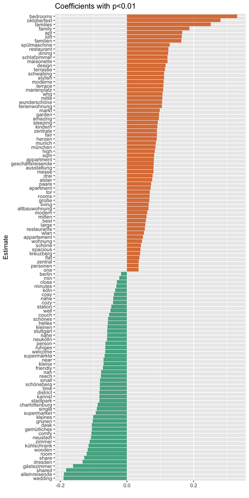

```r
library(broom)

tidy(lm.train) %>%
  filter(p.value < 0.01) %>%
  filter(term != "(Intercept)") %>%
  mutate(pos = factor(ifelse(estimate>=0,1,0))) %>%
  #top_n(20,estimate) %>%
  ggplot(aes(reorder(term, estimate),estimate,
             fill = pos)) +
  geom_col(show.legend = F, alpha = 0.8) +
  coord_flip() +
  scale_fill_manual(values = c(col[1],col[2])) +
  labs(x="Estimate", y="", title ="Coefficients with p<0.01")
```

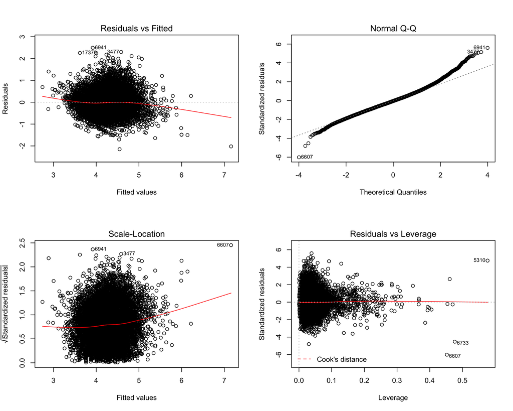

```r
par(mfrow=c(2,2))
plot(lm.train)
```

### (3) Make Predictions & Evaluate the model

Next, I use the trained model to make predictions on my test data.

```r
pred <- predict(lm.train, newdata = df.test)
```

```r
# Combine predictions with test dataframe
pred <- as.data.frame(pred)
pred$listing <- as.numeric(rownames(pred))
df.test$listing <- as.numeric(rownames(df.test))

pred.df <- left_join(pred, df.test %>%
                       select(log_price, listing),
                     by = "listing") %>%
  mutate(error = log_price-pred)
```

A plot of the predicted values for the price agains the actual values shows the explanatory power of the prediction model.

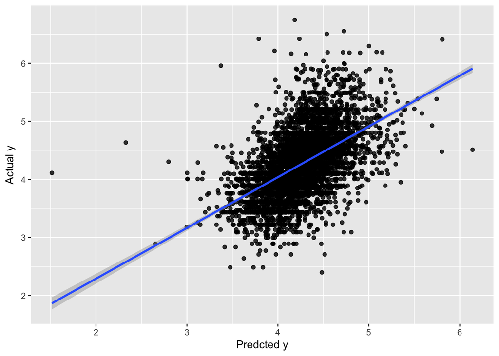

```r
ggplot(pred.df, aes(pred, log_price)) +
  geom_point(alpha = 0.8) +
  geom_smooth(method = lm) +
  labs(x="Predcted y", y="Actual y")
```

**RMSE**

```r
rmse <- function(error) {
  sqrt(mean(error^2))
  }

print(paste0("The RMSE is: ", rmse(pred.df$error)))
```

```
## [1] "The RMSE is: 0.469839522312849"
```

The variance of the price in the test dataset is helpful to get a better understanding of the RMSE value:

```r
print(paste0("The variance of log(price) is: ",var(df.test$log_price)))
```

```
## [1] "The variance of log(price) is: 0.306780240216699"
```

## Penalized Regression

```r
library(glmnet)
```

Ridge regression and the lasso are closely related, but only the Lasso has the ability to select predictors. Like OLS, ridge attempts to minimize residual sum of squares of predictors in a given model. However, ridge regression includes an additional ‘shrinkage’ term – the square of the coefficient estimate – which shrinks the estimate of the coefficients towards zero. The impact of this term is controlled by another term, lambda (determined seperately). Two interesting implications of this design are the facts that when $\lambda = 0$ the OLS coefficients are returned and when $\lambda = ∞$, coefficients will approach zero.